# Outline

### 1. Introduction

```
1.1. Brief Introduction of Dataset
1.2. Steps involved in Exploratory Analysis
```

### 2. Summary of Findings

```
2.1. Summary of findings obtained from the analysis
```

[output not shown]

### 4. Conclusion

# 1. Introduction

### 1.1. Brief Introduction of Dataset

There are several datasets provided to complete this project. I will be working with the Ford GoBike System Data. This data set includes information about individual rides made in a bike-sharing system covering the greater San Francisco Bay area.

[figure not shown]

This data covers the major information about the Ford GoBike System, it includes variables like;

- duration_sec - Duration of travel in seconds
- start_station_id - Start Station Unique Identification
- start_station_latitude - Start Station Latitude
- start_station_longitude - Start Station Longitude
- end_station_id - End Station Unique Identification
- end_station_latitude - End Station Latitude
- end_station_longitude - End Station Longitude
- bike_id - Bike Unique Identification
- user_type - Bike User Types
- member_birth_year - Member Birth Year

### 1.2. Steps involved in Exploratory Analysis

The following steps were considered during the Exploratory Analysis

1. Import of Neccessary Python Libraries needed for the analysis like; pandas, matplotlib, numpy, etc.
2. Loading of the dataset into the python Pandas DataFrame, using the pd.read_csv(data.csv) method
3. Performed Data Understanding. Here, I did a form of data understanding where I got acquainted with the variables to be used during the analysis
4. Then I accessed the data to check for errors and irregularities in the dataset. Here, I observed three errors that are peculiar to this data. They are;
   - Date and Time being merged together
   - Missing Values in a few columns of the dataset
   - Wrong datatypes for variables
5. After I discovered the above listed errors, I performed data cleaning process to tidy the data from the errors being observed.
6. Data Exploration: Here, I performed three major form analysis. They include;
   - Univariate Analysis
   - Bivariate Analysis
   - Multivariate Analysis
7. Documentation of Findings

# 2. Summary of Findings

### 2.1. Summary of findings obtained from the analysis

From my exploratory analysis, the insights obtained can be broadly classified into three;

1. Insights from Univariate Analysis
2. Insights from Bivariate Analysis
3. Insights from Multivariate Analysis

#### 1. Insights form Univariate Analysis:

Here, there are several insights deduced and obtained. Some of which include;

- Barplot to show the gender percentage which participated in the system. From this, Male gender recorded the highest participants, Female gender the second and the Others the third.

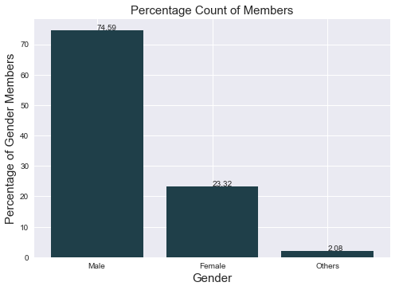

- Distribution Plot: This plot was used to identify the birth year range of members who participated in the system. Here, we will notice that the majority of the members are in the range of 1960 - 2000

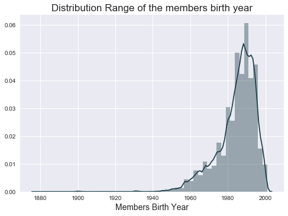

- Pie Chart: This was used to acertain the percentage of the bike system user type. The plot shows that the 90.53% are subscribers while 9.47% are customers

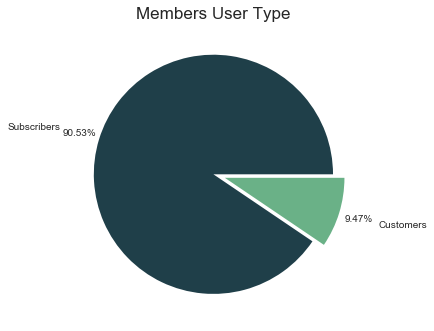

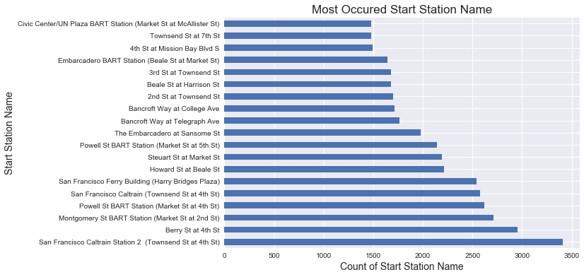

#### 2. Insights form Bivariate Analysis:

Here are the following insights were obtained;

- Scatterplot: The scatterplot was used to distance between the start lattitude and the end latitude. It shows by how far the start latitude is from the end latitude. It ascertain the claims that the start latitude is linearly correllated to the end latitude

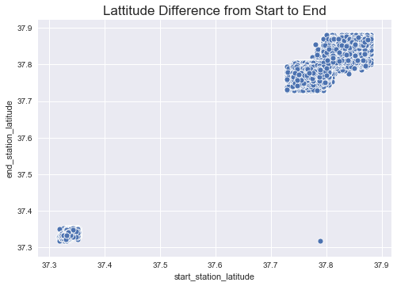

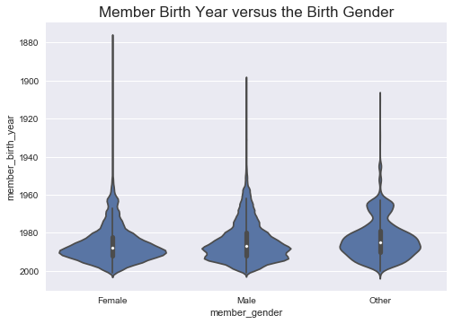

- Hue countplot: Here, the plot shows a countplot of the member gender with respect to the user type. From this, the highest number members are male, with subscribers user type being predorminant.

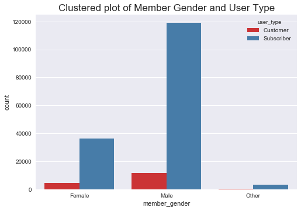

- PointPlot: The Pointplot showed the trend of members gender with respect to their birth year. There is a continuous decline in the birth year of the members.

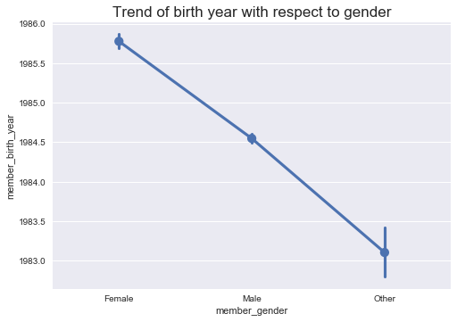

#### 3. Insights from multivariate analysis.

- Mulivariate Scatterplot: This plot was used to estimate the duration if each bike, which indicated that most bikes completed the trip in less than 20000 secs. And younger members were predorminant in the system.

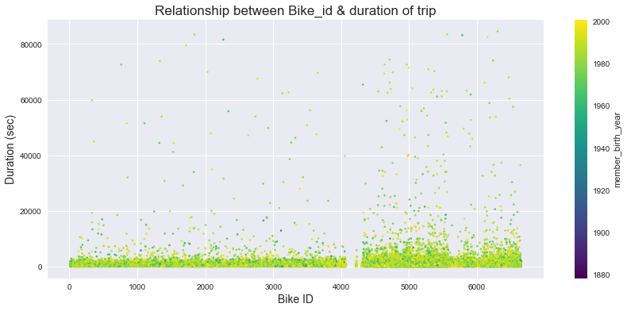

- Boxplot: Here, we realise that there were several outliers. Indicating the presence of aged members in the bike system.

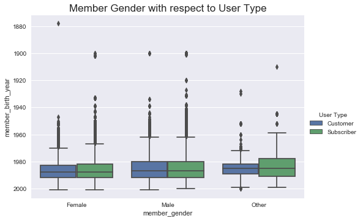

# Conclusion

From the analysis, I observed the following which will help in decision making.

1. The majority of the members in the bike system are male.
2. The range of members birth year in the system is between 1960 - 2000
3. The subscribers user type are much more that the other users.